# Exercise 11.1

# Preamble

## Import Library

The following code will automatically install packages that are not already installed and load them into the library:

```r
if(require('pacman')){
  library('pacman')
}else{
  install.packages('pacman')
  library('pacman')
}
```

```r
pacman::p_load(sp, EnvStats, gstat, ggplot2, rmarkdown)
```

## Create Assignments

Note that Benthic.df is included in the *EnvStats* package and is not a data frame but an *sp* class, which is very similar to a data frame

```r
#Assignments
benthic <- Benthic.df
lat <- benthic$Latitude
lon <- benthic$Longitude
```

# Inspect the Data Set

```r
head(benthic, 3)
```

```
##   Site.ID Stratum Latitude Longitude Index Salinity Silt
## 1 89/90-1     101  38.4430  -76.4457  2.33      2.0  0.6
## 2 89/90-1     101  38.4232  -76.4237  3.67      2.0  0.8
## 3 89/90-1     101  38.4773  -76.4827  2.00      1.5  0.6
```

# Asign Co-ordinates

The benthic data set is not a mere data frame, it is an `sp` object, which is very similar to a data frame. It is necessary to set the co-ordinates of this object though:

```r
coordinates(benthic) = ~Longitude + Latitude
```

# Create a variogram

A variogram is a description of the structure of spacial data, first this needs to be created before anything can be plotted or modelled:

```r
benthic.vg <- variogram(Index ~ 1, data = benthic)
```

Now we can inspect the variogram:

```r
head(benthic.vg)
```

```
##     np       dist     gamma dir.hor dir.ver   id
## 1 4545 0.02410565 0.8500134       0       0 var1
## 2 4149 0.06703996 0.9606919       0       0 var1
## 3 3883 0.11396396 1.2417457       0       0 var1
## 4 4023 0.16138943 1.6066269       0       0 var1
## 5 5963 0.20615519 1.7325016       0       0 var1
## 6 6732 0.24983031 2.0285331       0       0 var1
```

By observing this, we can conclude, that a variogram will have an $x$-axis of `dist` and a $y$-axis of `gamma`.

# Plot the Variogram

## Create a base plot of that variogram

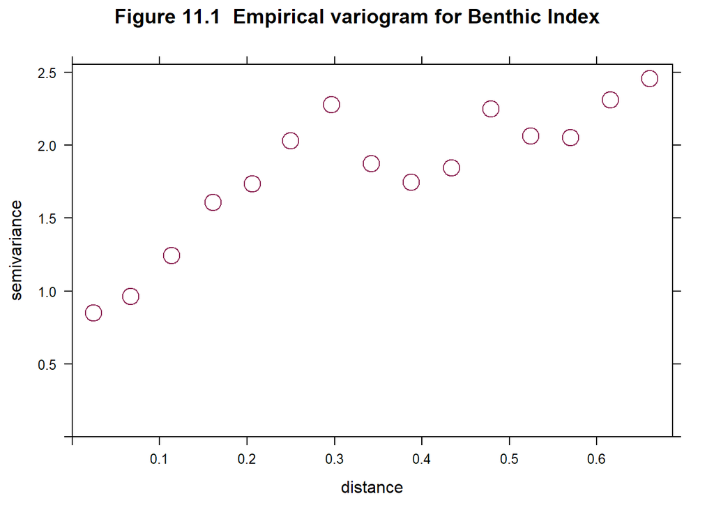

```r
plot(benthic.vg, main="Figure 11.1  Empirical variogram for Benthic Index",
     col = 'violetred4', cex = 2)
```

## Create an attractive plot in ggplot

The `ggplot2` package makes it reasonable easy to add a non-parametric model using the $loess$ method:

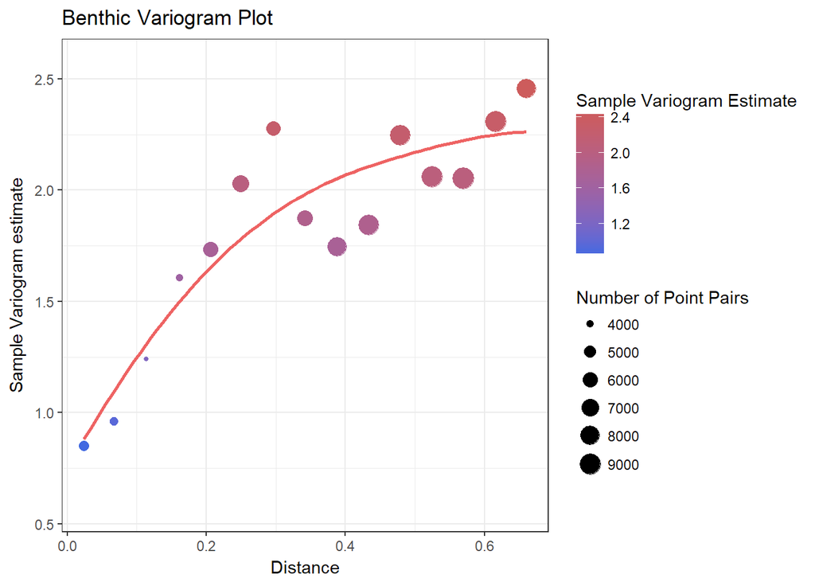

```r
ggplot(data = benthic.vg, aes(x = dist, y = gamma, col = gamma, size = np)) +
  geom_point() +
  scale_color_continuous(low = 'royalblue', high = 'indianred') +
  labs(size = "Number of Point Pairs", col = "Sample Variogram Estimate",
       y = "Sample Variogram estimate", x = "Distance",
       title = 'Benthic Variogram Plot') +
  theme_bw() +
  geom_smooth(se = TRUE, fill = 'purple', alpha = 0,
              size = 1, span = 2, col = 'indianred2')
```

# Create Variogram Models

Variogram models are objects of the class `variogramModel` and cannot be drawn with `ggplot2`, hence only base plots can be used to draw a parametric model over the variogram plot.

## Exponential Model

An exponential model is of the form:

$C(h) = \sigma^2 \times e^{\frac{-h}{r}}$

and can be modelled:

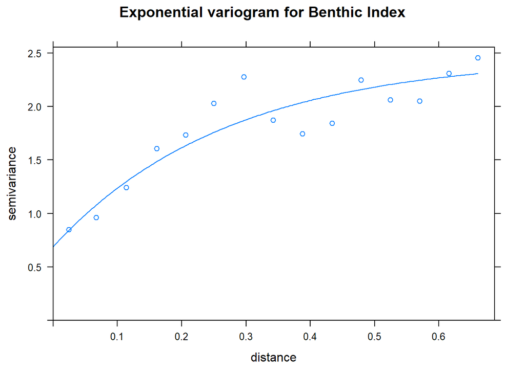

```r
benthic.vg.fit.exp <- fit.variogram(benthic.vg,
                                    model=vgm(1,"Exp", 0.5,1))
plot(benthic.vg, benthic.vg.fit.exp,
     main="Exponential variogram for Benthic Index")
```

# Gaussian Model:

A Gaussian model is of the form:

$C(h) = \sigma^2 \times e^{({\frac{-h}{r}})^2}$

and can be modelled:

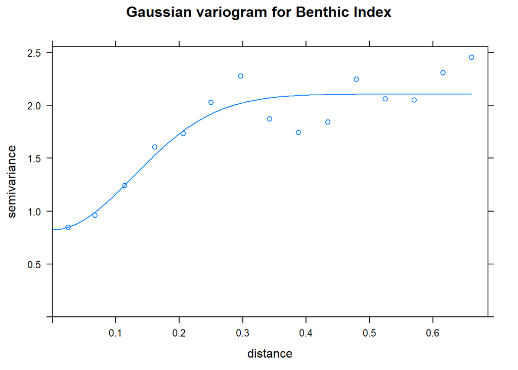

```r
benthic.vg.fit.gau <- fit.variogram(benthic.vg,
                                    model=vgm(1,"Gau", 0.5,1))
plot(benthic.vg, benthic.vg.fit.gau,
     main="Gaussian variogram for Benthic Index")
```

# Spherical Model:

A sperical model is of the form:

$C(h) = \sigma^2 \times (1 - \frac{3h}{2r} + \frac{h^2}{2r^3})$

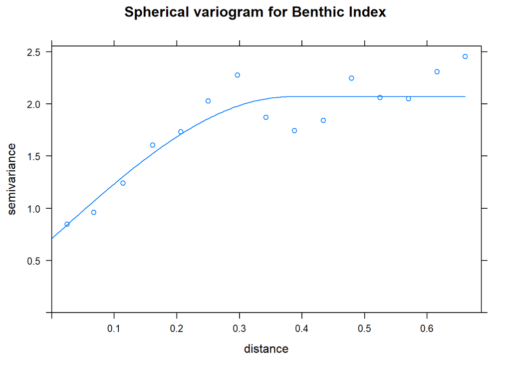

```r
benthic.vg.fit.sph <- fit.variogram(benthic.vg,
                                    model=vgm(1,"Sph", 0.5,1))
plot(benthic.vg, benthic.vg.fit.sph,
     main="Spherical variogram for Benthic Index")
```

# Directional Variogram

Because a directional variogram is still of the class `variogramModel`, it is not possible (to the best of my knowledge) to use `ggplot2` in order to plot it.

The `alpha` option allows a vector of directional degrees to be specified, in this case, 0, 45, 90 and 135.

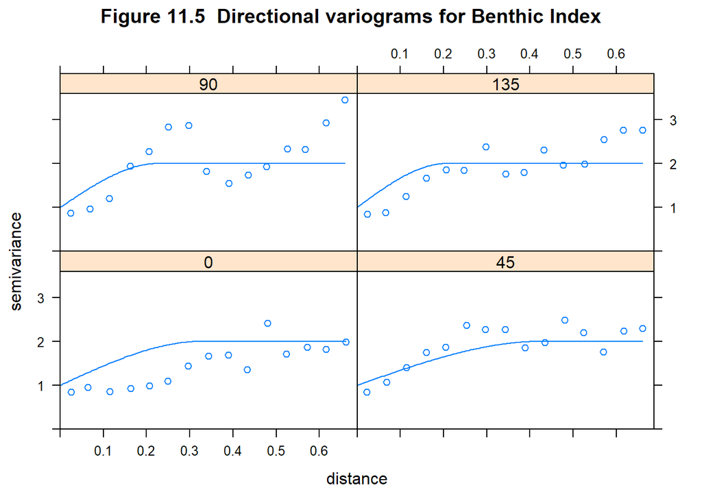

```r
benthic.dvg <- variogram(Index ~ 1,
                         data=benthic, alpha=c(0, 45,90,135))
benthic.dvg.fit <- vgm(1,"Sph", 0.5,1,anis=c(30,0.4))
plot(benthic.dvg, benthic.dvg.fit,
     main="Figure 11.5  Directional variograms for Benthic Index")
```